# A simulation study based on Wilcoxon Signed Rank Test

Abhirup Sengupta, Subhasis Sur , Shantanu Nayek

2023-03-18

## Introduction

- Wilcoxon Signed Rank Test is a non parametric test for one sample location problem .
- We assume that $X_1 , X_2 , ...., X_n$ is a iid sample from $F(x-\theta)$ , where F belongs to a location family is continuous and symmetric about 0 and F(0) = 1/2

Now , we want to test the null hypothesis $H_0$ against some alternative hypothesis

- $H_1$ : $\theta$ > 0
- $H_2$ : $\theta$ < 0
- $H_3$ : $\theta$ $\neq$ 0

## Distribution free of the test statistic under H_0 for n = 10 :

- Here we have taken the four distributions ( Normal , Cauchy , Laplace and logistic ) which satisfies the assumptions .

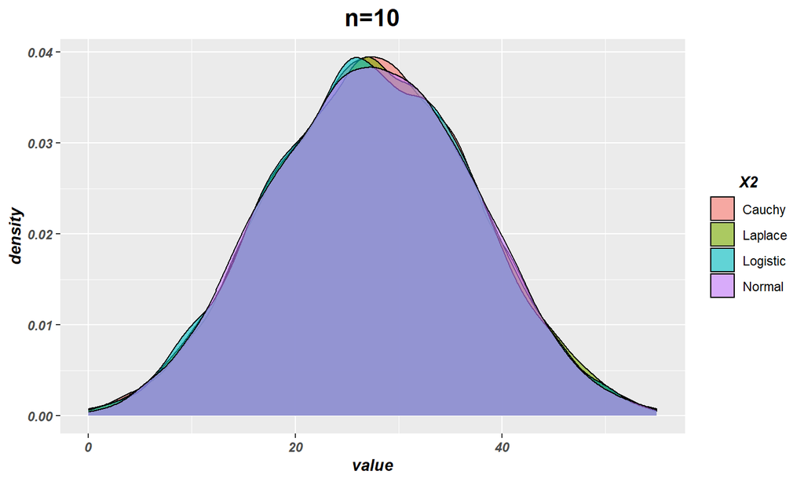

- The test statistic is distribution free under H_0 for n = 10 .

## Distribution free of the test statistic under H_0 for n = 20 :

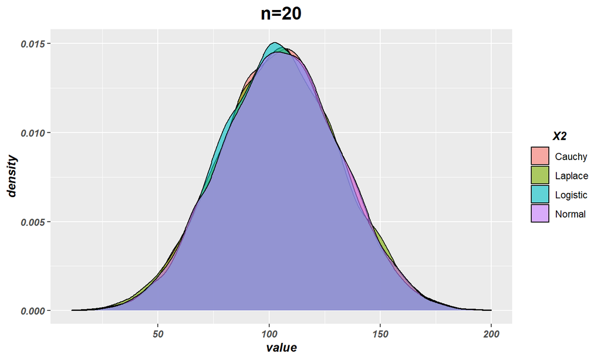

- The test statistic is distribution free under H_0 for n = 20 .

## Distribution free under H_0 for n = 30 :

- We repeat this process for n = 30 .

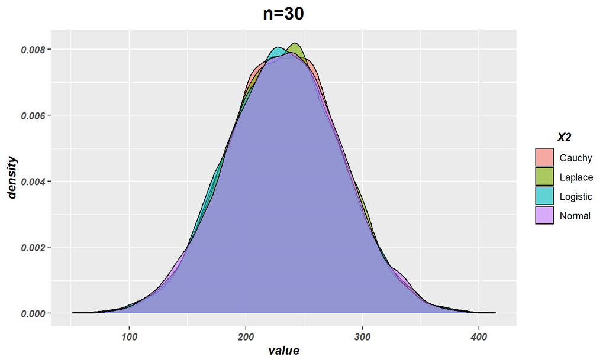

- The test statistic is distribution free under H_0 for n = 30

## Distribution free under H_0 for n = 50 :

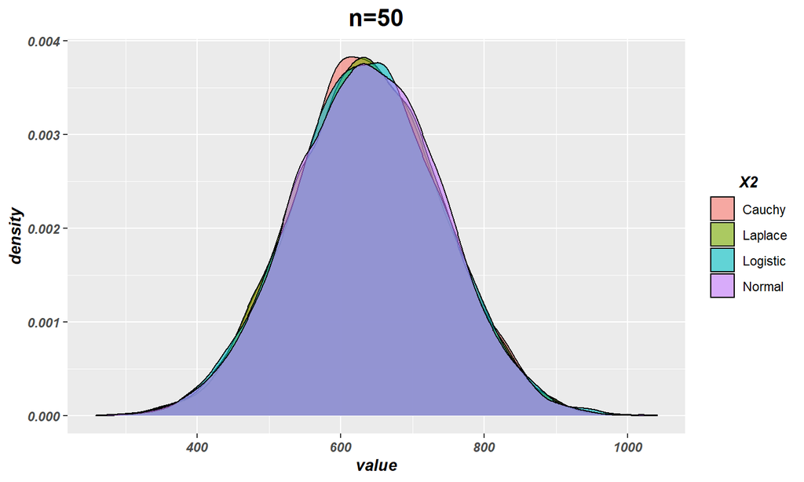

- The test statistic is distribution free under H_0 for n = 50 .

## Distribution free under H_0 for n = 100 :

- We repeat this process also for n = 100 .

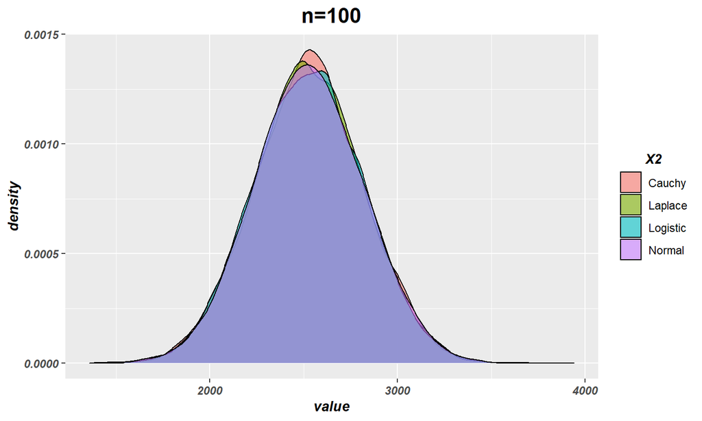

- The test statistic is distribution free under H_0 for n = 100 .

## Checking Distribution free under H_1 for n = 10 :

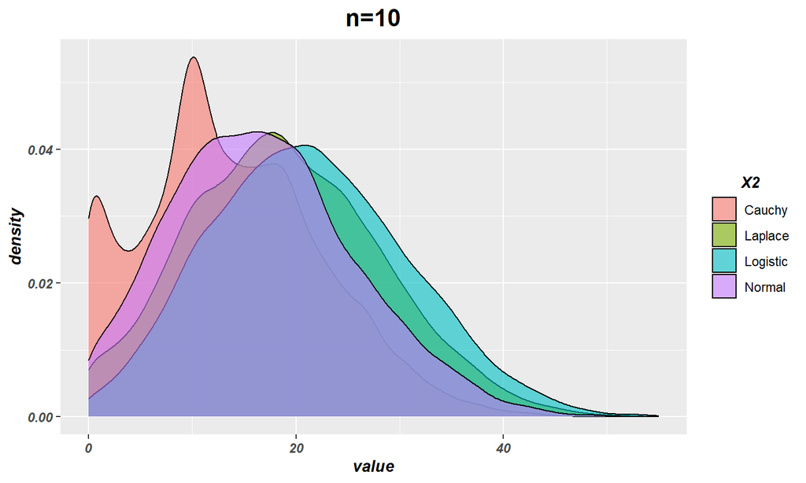

- It is not distribution free

## Checking Distribution free under H_1 for n = 20 :

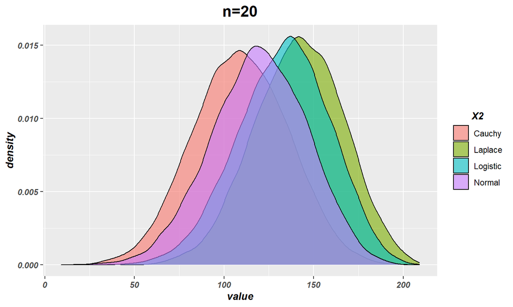

## Checking Distribution free under H_1 for n = 30 :

- We repeat the same process as before .

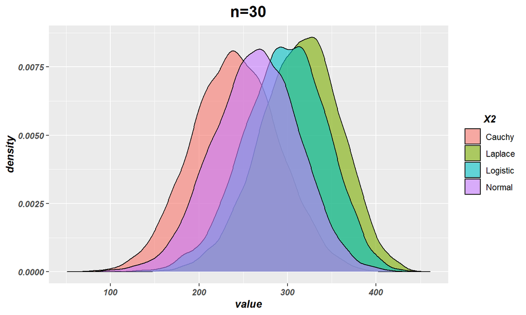

## Checking Distribution free under H_1 for n = 50 :

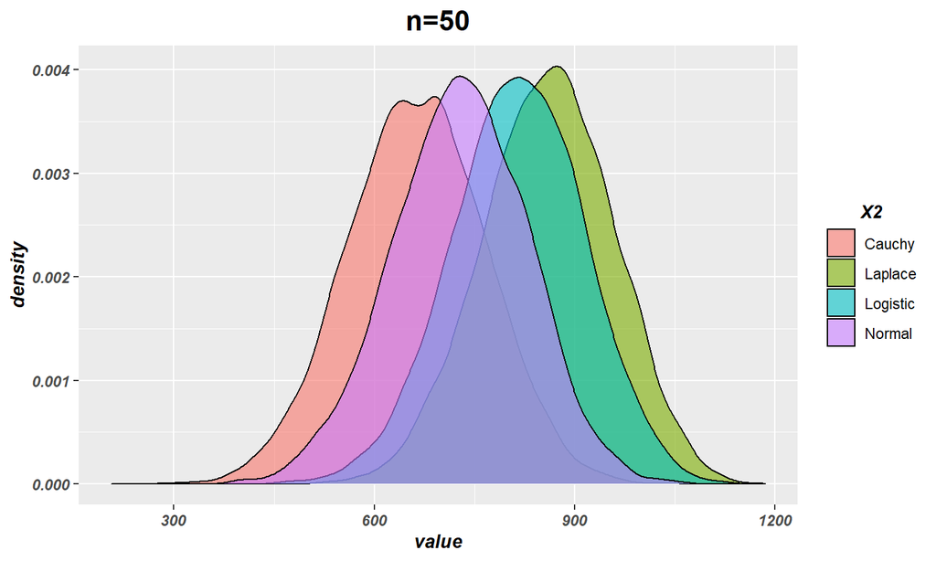

## Exact Distribution of Wilcoxon Signed Rank Test statistic for Normal Distributions for n = 10 :

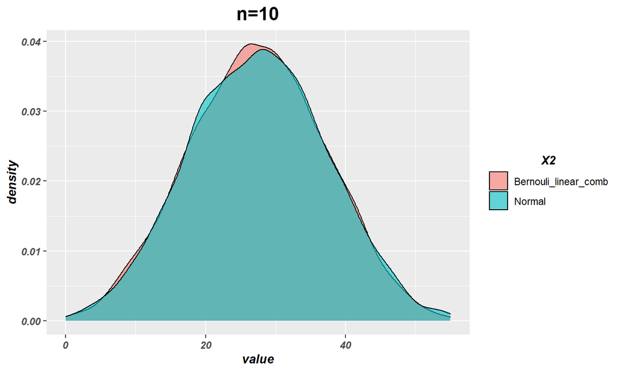

- from the plot , clearly both are same for normal distribution for sample sizes n = 10 .

## Exact Distributions of Wilcoxon Signed Rank Test Statistic for Normal distribution for n = 30 :

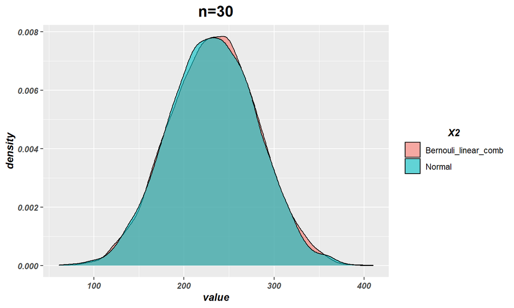

- from the plot , clearly both are same for normal distribution for sample sizes n = 30 .

## Exact Distributions of Wilcoxon Signed Rank Test Statistic for Cauchy distributions for n = 10 :

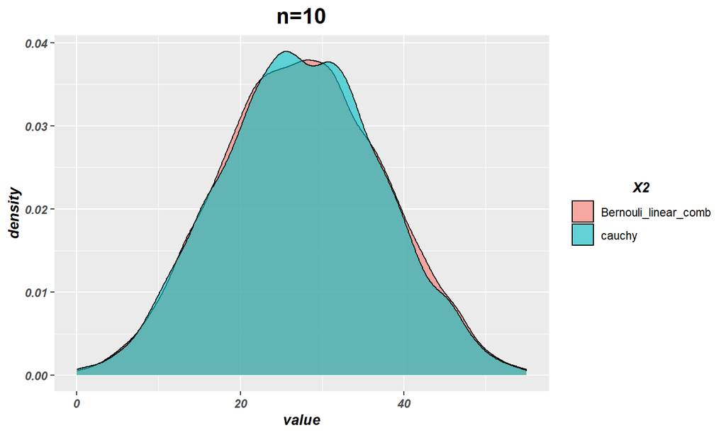

- from the plot , clearly both are same for cauchy distribution for sample sizes n = 10 .

## Exact Distributions of Wilcoxon Signed Rank Test Statistic for Cauchy distribution for n = 30 :

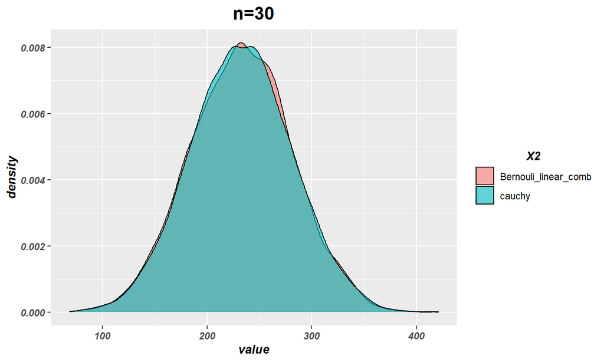

- from the plot , clearly both are same for Cauchy distribution for sample sizes n = 30 .

## Violation of Assumption ( Continuous assumption is violated) :

- we draw the random sample from a discrete distributions namely, Poisson Distributions with parameter 2 .
- Then we do the same process as before for sample sizes n = 10 .

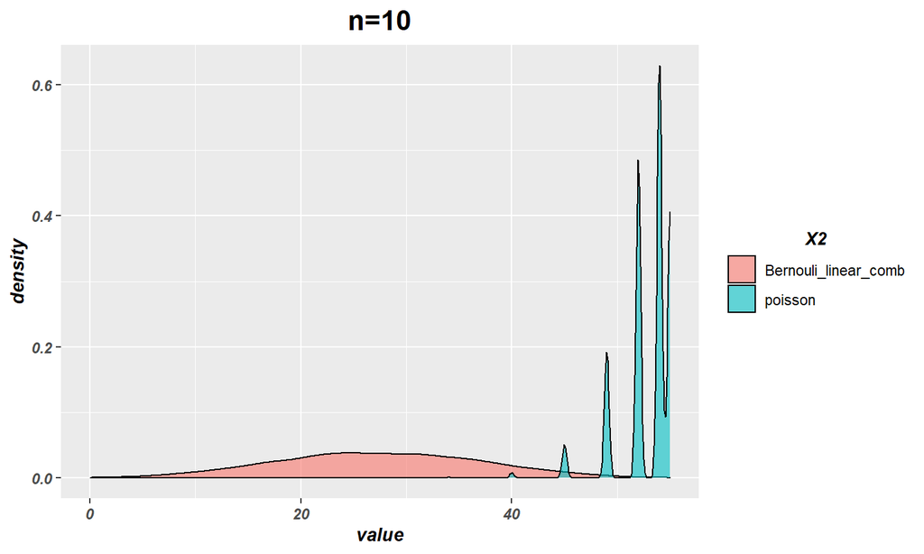

- from the plot , it is observed that both are not same .
- taking n = 30
- We do the same process as before for n = 30 .

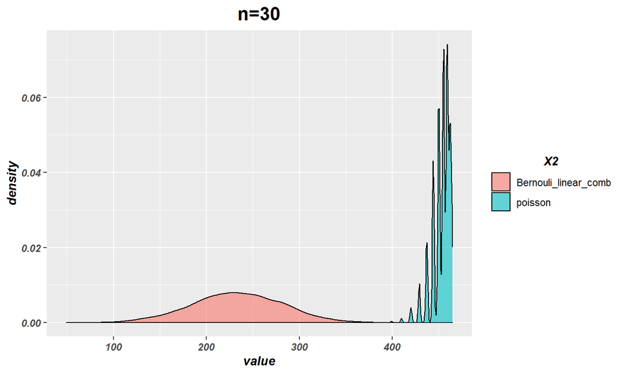

- from the plot , it is observed that both are not same .

## Violation of Assumption ( Symmetricity assumption is violated) :

- we draw the random sample from a non-symmetric distributions namely, Exponential Distributions with parameter 2 .
- then We do the same process as before for sample sizes n = 10 .

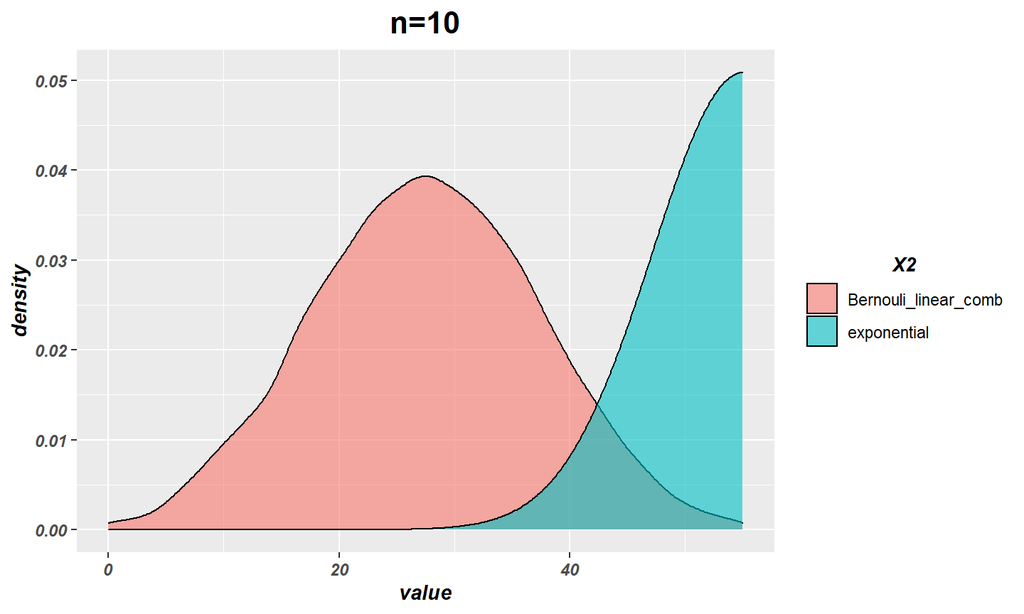

- Both distributions are not same . This thing happens for violation of symmetry of F .

We do the same process taking random sample of sizes n = 30 from exponential distributions .

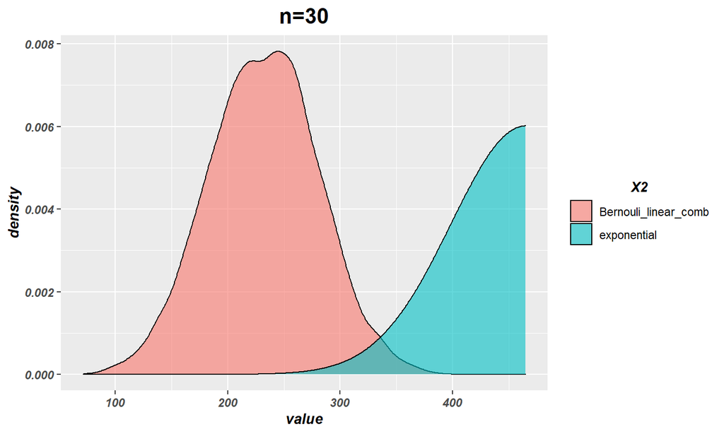

- Both distributions are not same . This thing happens for violation of symmetry of F .

## Checking Wilcoxon Signed Rank Test can be written as the number of Walsh Averages

- We draw a random sample of size n = 10 from cauchy distributions and find the values of Walsh Averages . We repeat this process upto 10,000 times .

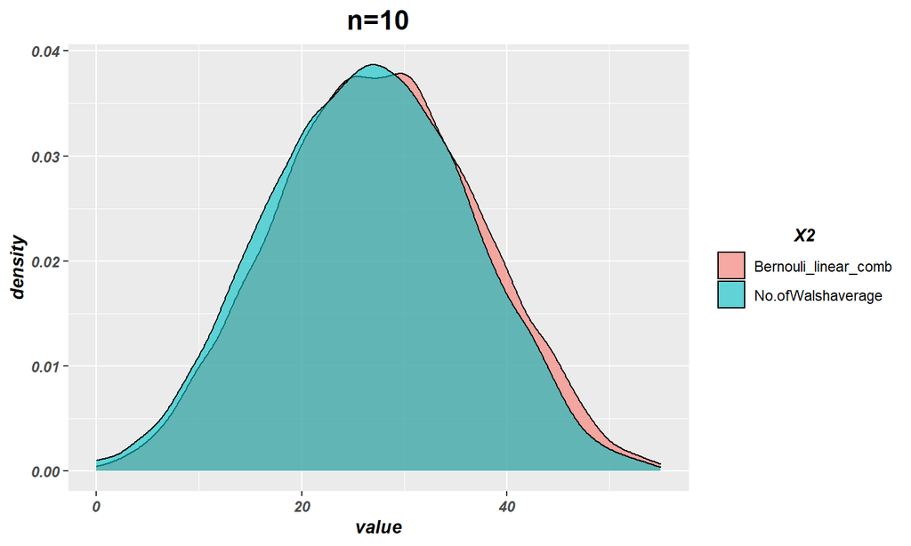

## Taking Sample sizes n = 20

- We do the same process as before by taking random sample from Cauchy distributions for n = 20 .

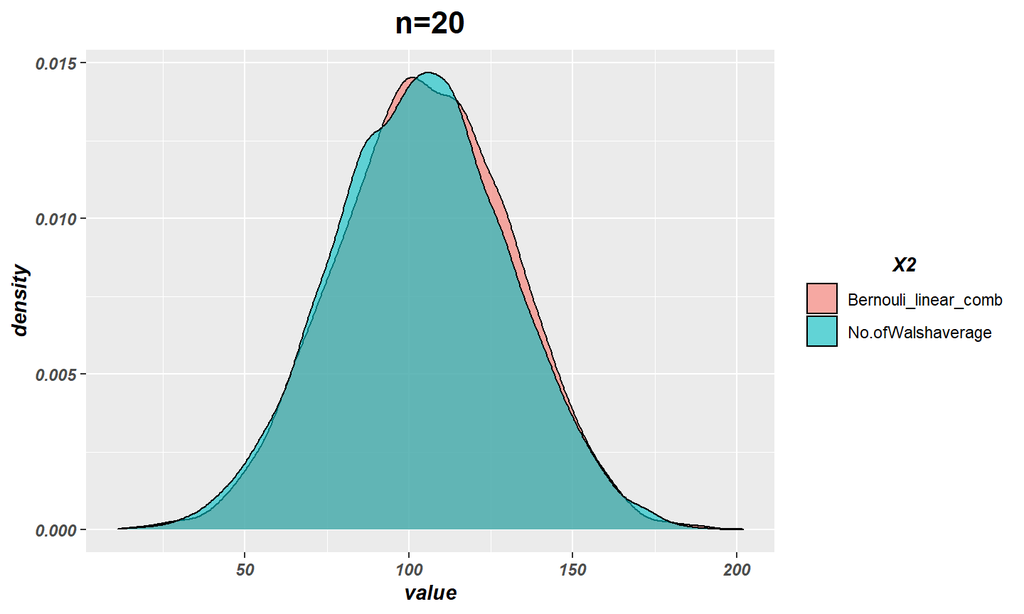

```r
x=array(0)
```

## Asymptotic Distribution of Test Statistic Under H0

- No. of replication = 10000
- Normal(0,2)
- n = 10

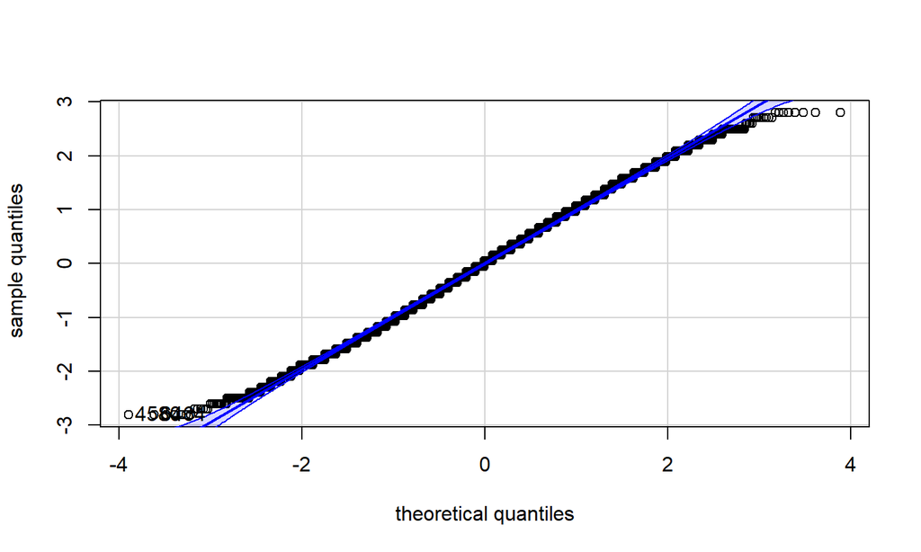

```
## [1] 4580 6464
```

- n = 20

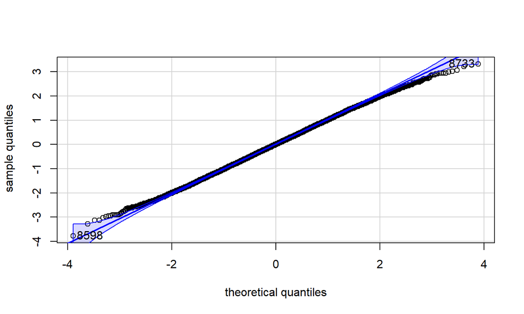

```
## [1] 8598 8733
```

- n = 30

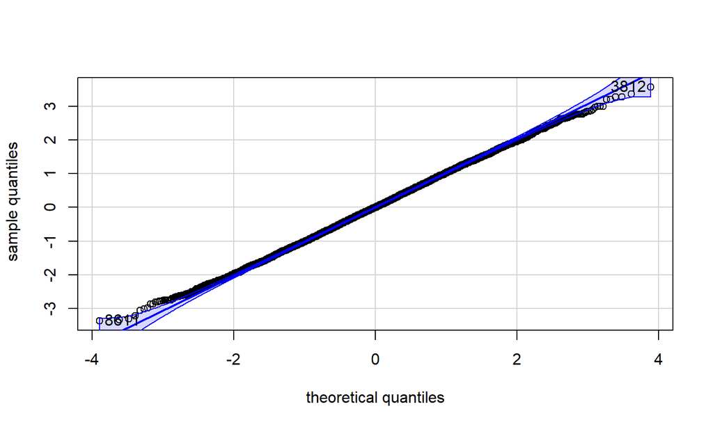

```
## [1] 3812 8611
```

- n = 50

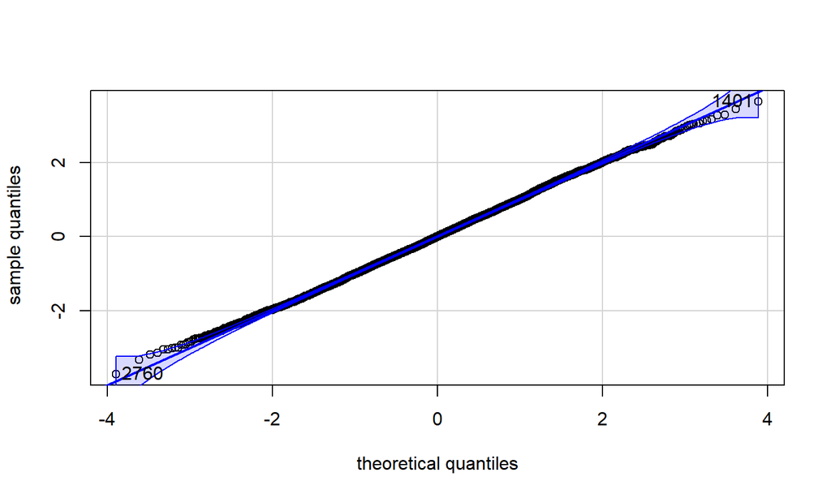

```
## [1] 2760 1401
```

- n = 100

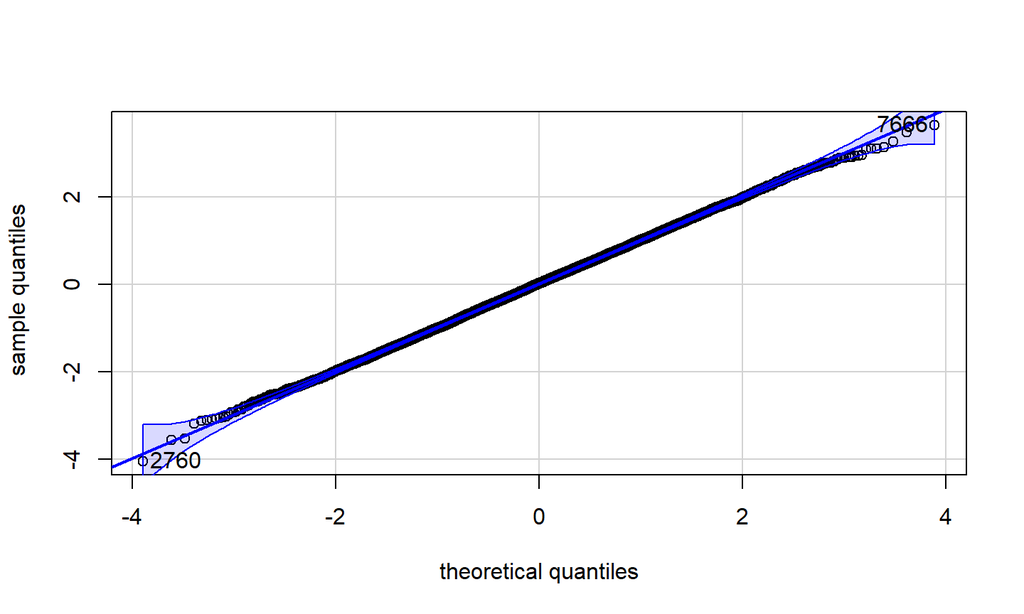

```
## [1] 2760 7666
```

- n = 200

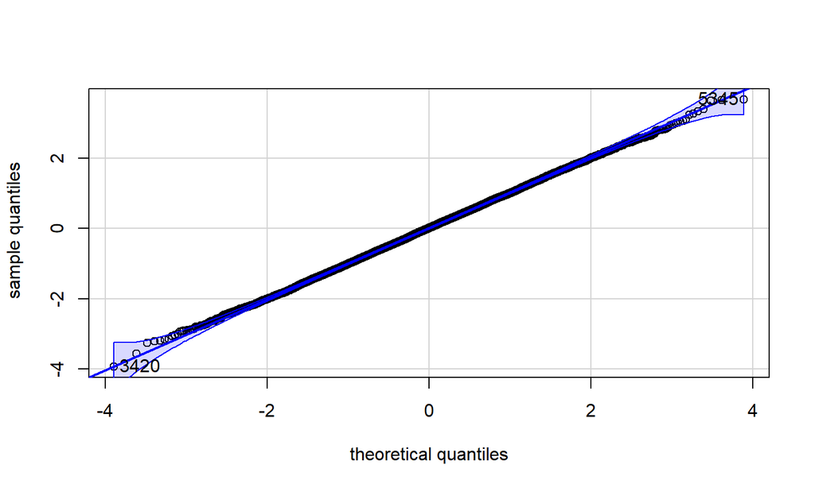

```
## [1] 3420 5345
```

## Goodness of fit with normal(0,1)

```
##   sample size      p value
## 1          10 7.837699e-05
## 2          20 3.259445e-02
## 3          30 6.104124e-01
## 4          50 7.344442e-01
## 5         100 5.295176e-01
## 6         200 8.928889e-01
```

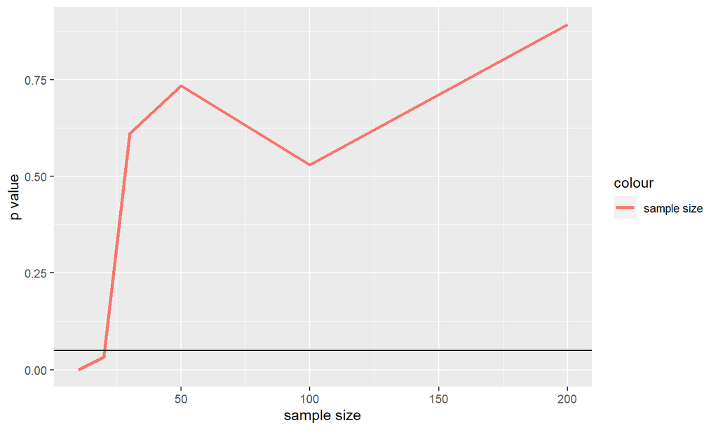

- converge to normal(0,1) for n between 20 to 30

- Cauchy (0,2)
- n = 10

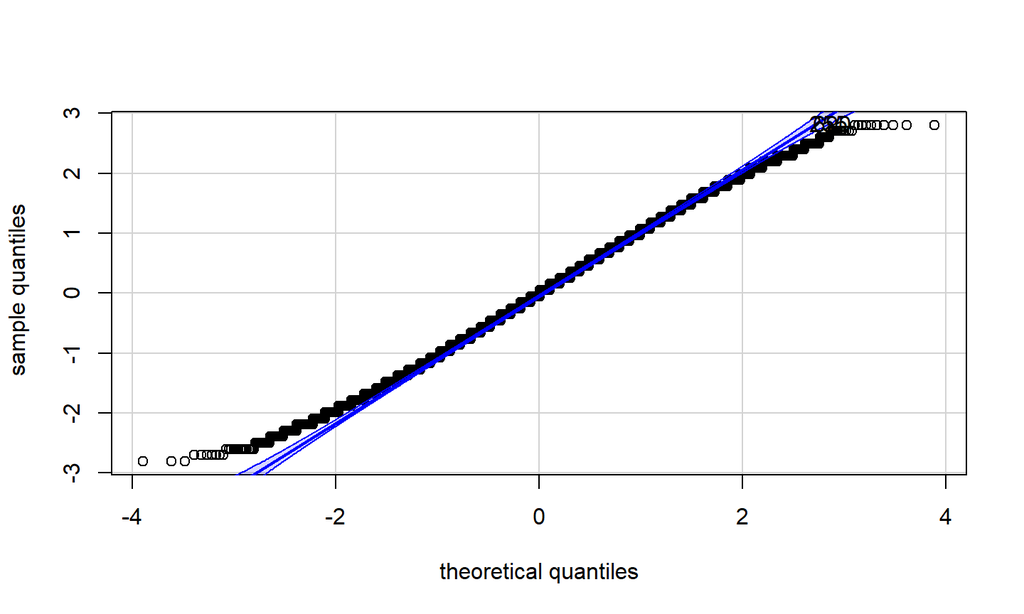

```
## [1] 255 690
```

- n = 20

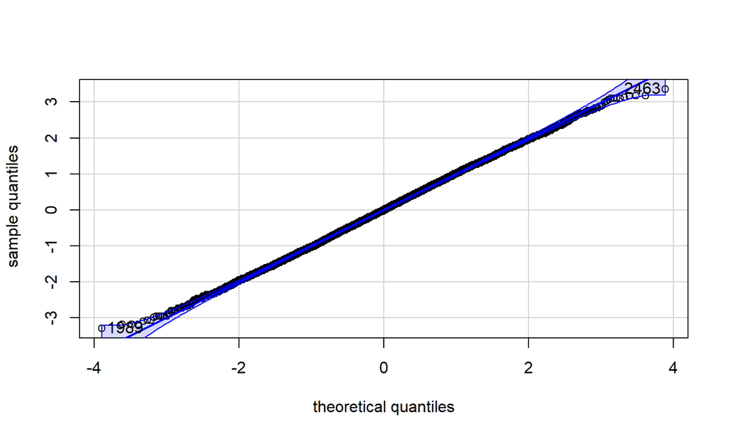

```
## [1] 2463 1989
```

- n = 30

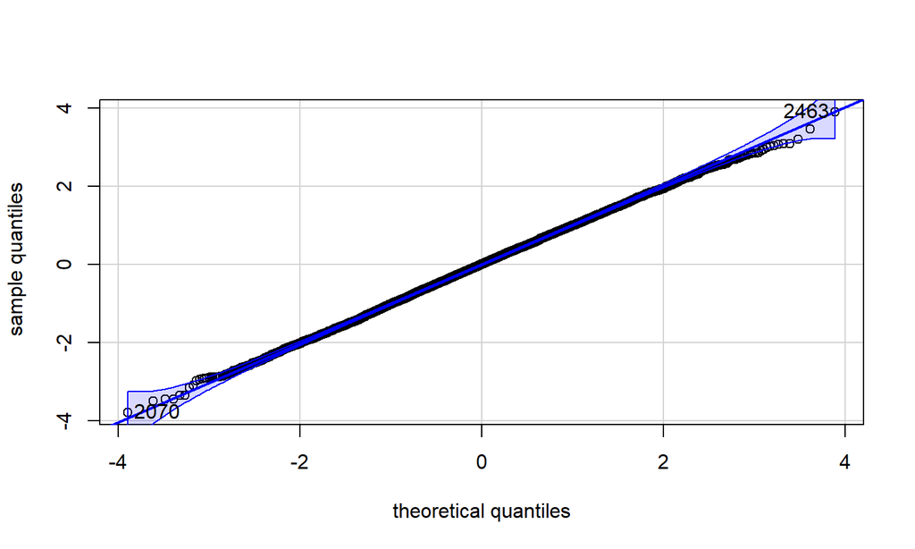

```
## [1] 2463 2070
```

- n = 50

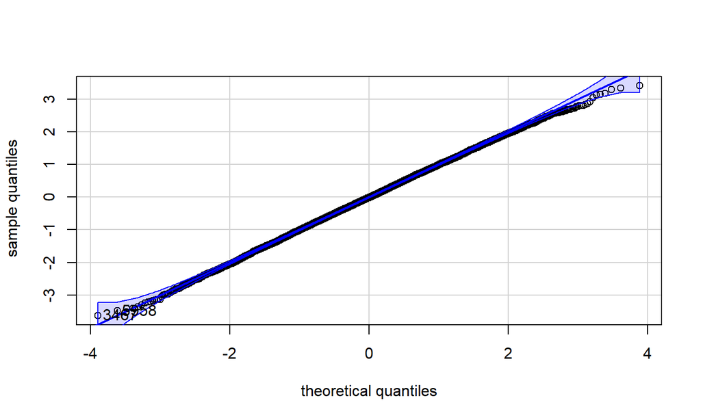

```
## [1] 3467 5958
```

- n = 100

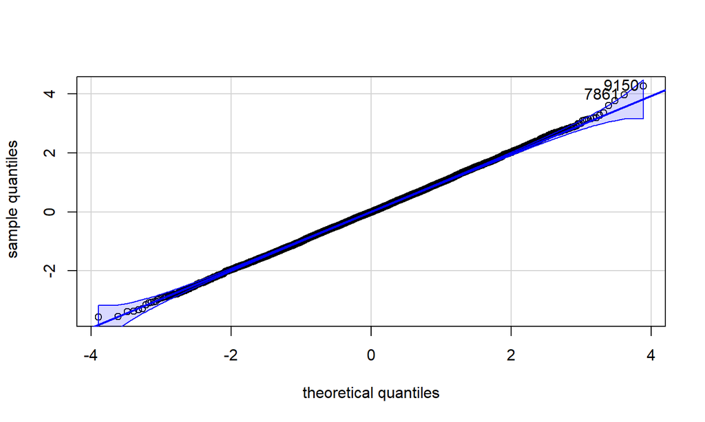

```
## [1] 9150 7861
```

- n = 200

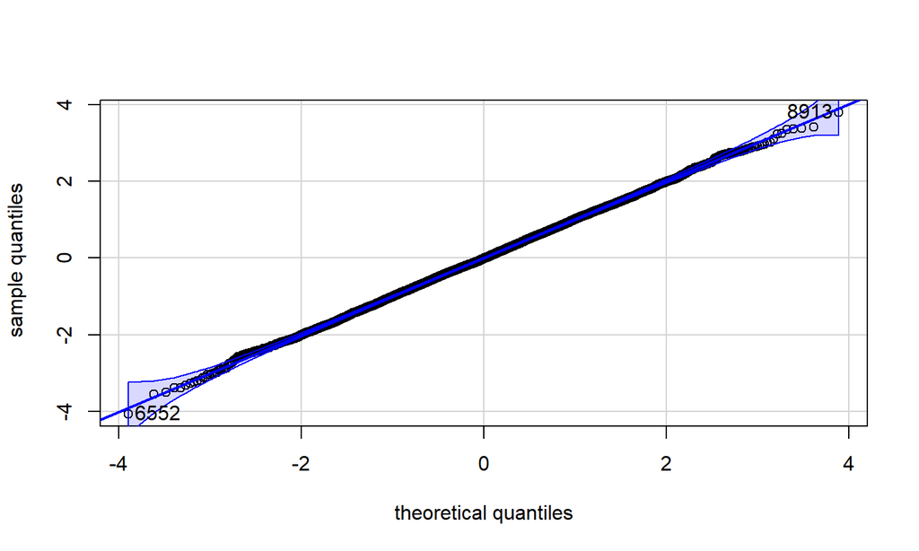

```
## [1] 6552 8913
```

## Goodness of fit with normal(0,1)

```
##   sample size      p value
## 1          10 0.0001854553
## 2          20 0.0001141394
## 3          30 0.3128576168
## 4          50 0.0894543127
## 5         100 0.3826442268
## 6         200 0.7645099324
```

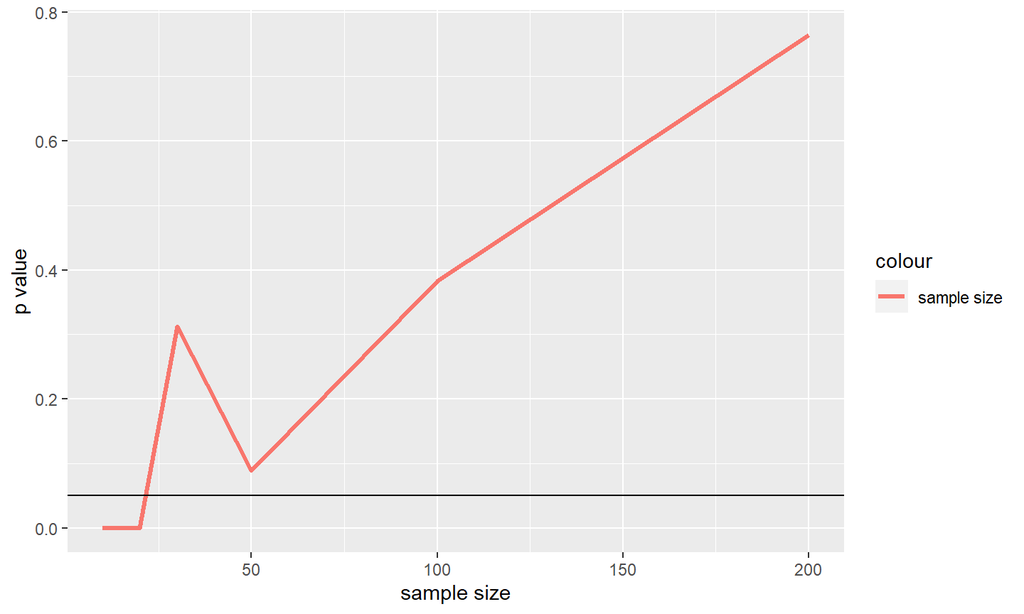

- converge to normal(0,1) for n between 20 to 30

## Asymptotic Distribution of Test Statistic Under H1

- Normal(-1,2)
- n = 10
- Calculate the test statistic
- Normalize the data by $(x-mean(x))/sd(x)$

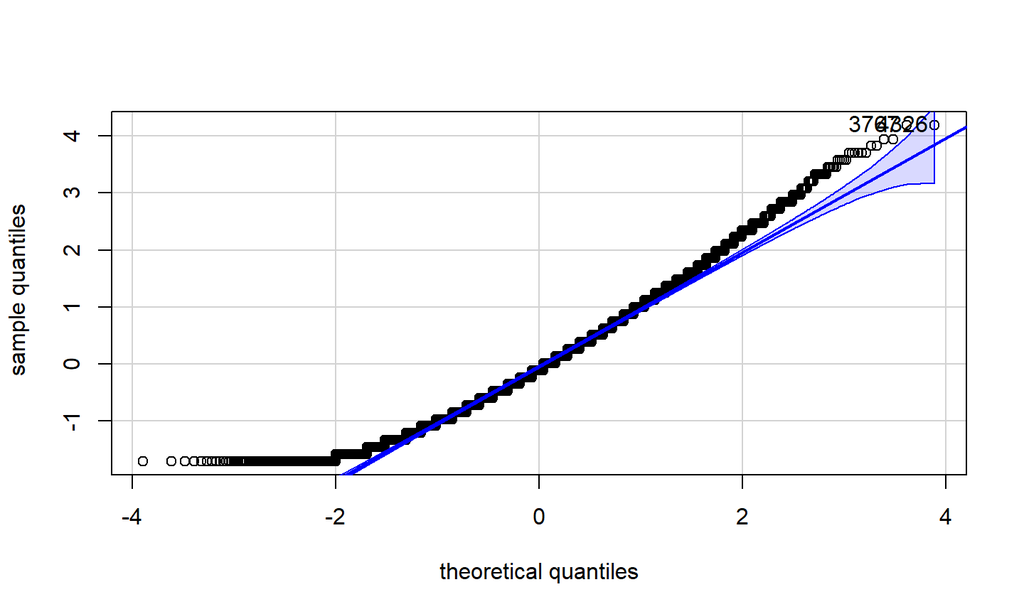

```
## [1] 3767 4326
```

- n = 20

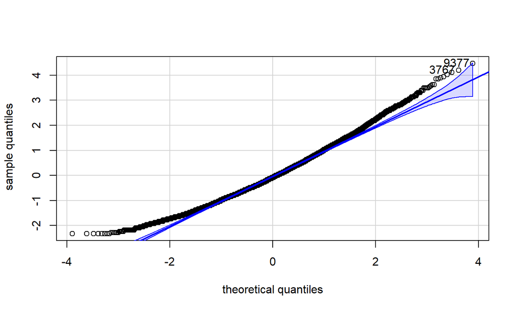

```
## [1] 9377 3767
```

- n = 30

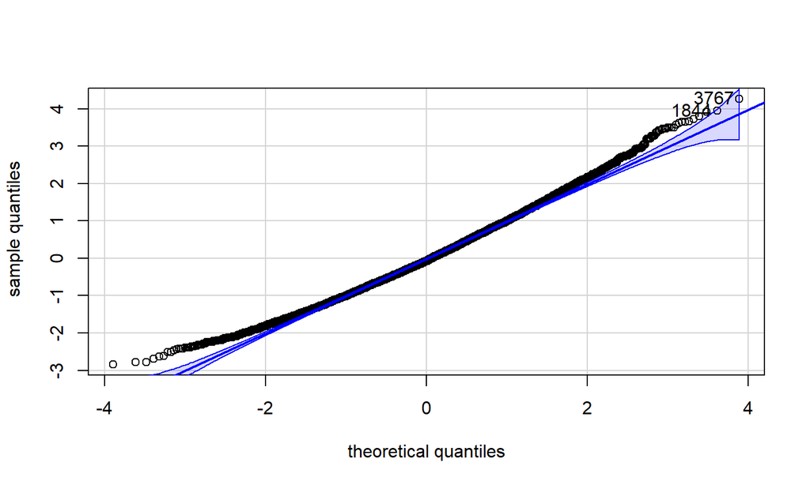

```
## [1] 3767 1844
```

- n = 50

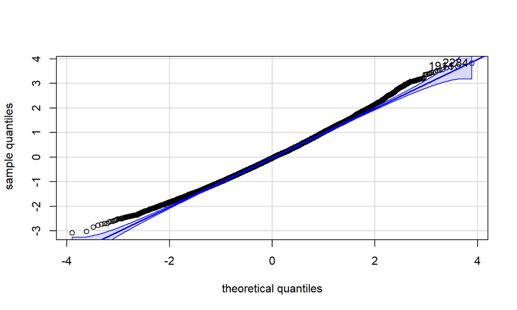

```
## [1] 2284 1911
```

- n = 100

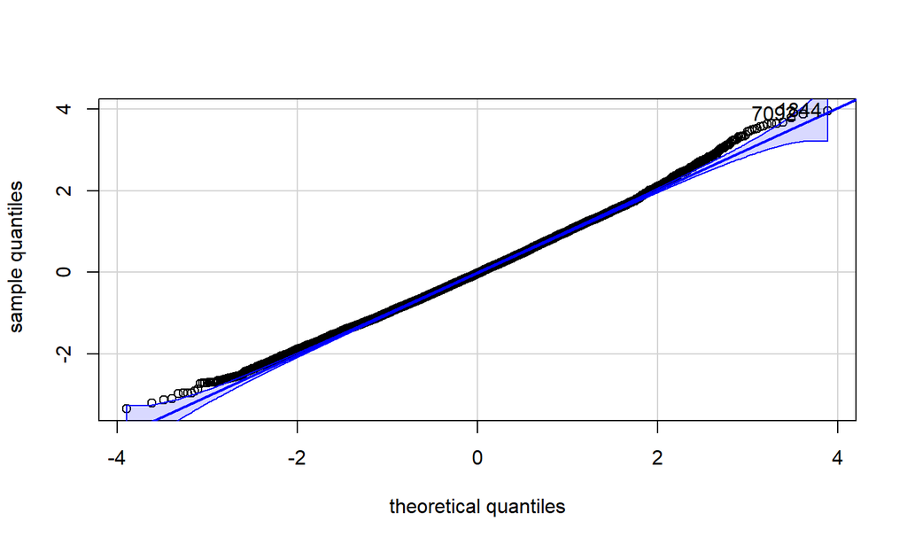

```
## [1] 1844 7092
```

- n = 200

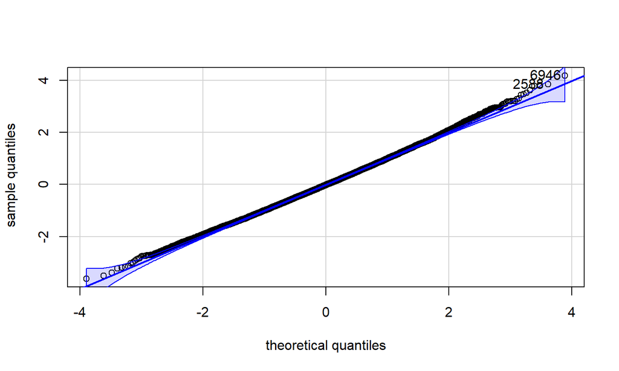

```
## [1] 6946 2588
```

- n = 250

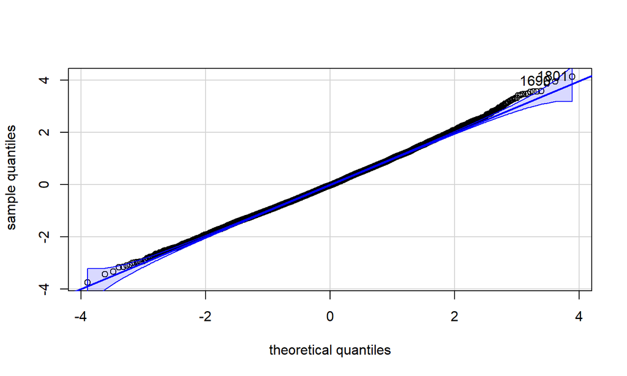

```
## [1] 1801 1690
```

- n = 300

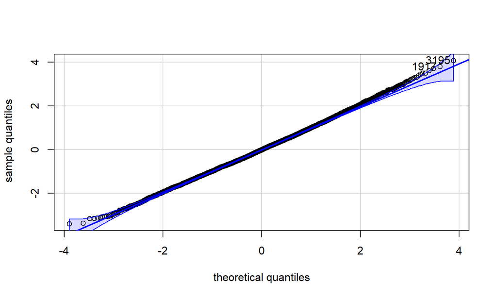

```
## [1] 3195 1917
```

## Goodness of fit with normal(0,1)

```
##   sample size      p value
## 1          10 4.106548e-65
## 2          20 8.668193e-40
## 3          30 1.556719e-21
## 4          50 1.284159e-11
## 5         100 2.515082e-04
## 6         200 8.619595e-03
## 7         250 1.405013e-03
## 8         300 1.203184e-01
```

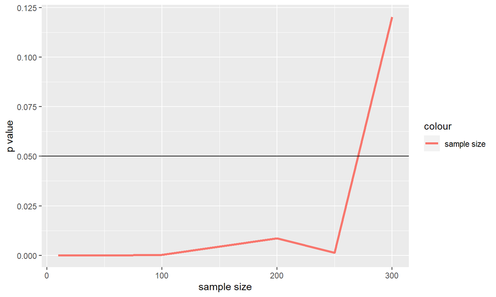

## Cauchy(1,2)

- n = 10

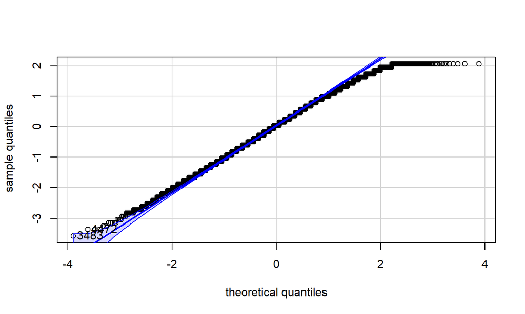

```
## [1] 3483 4472
```

- n = 20

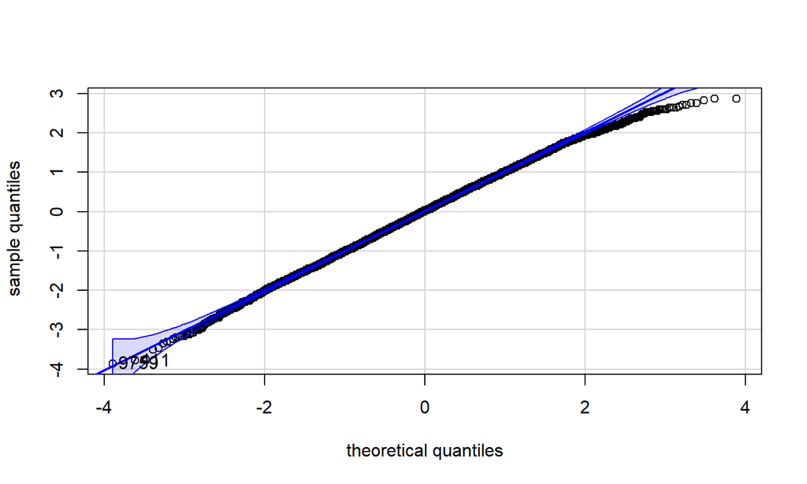

```
## [1] 9759  411
```

- n = 30

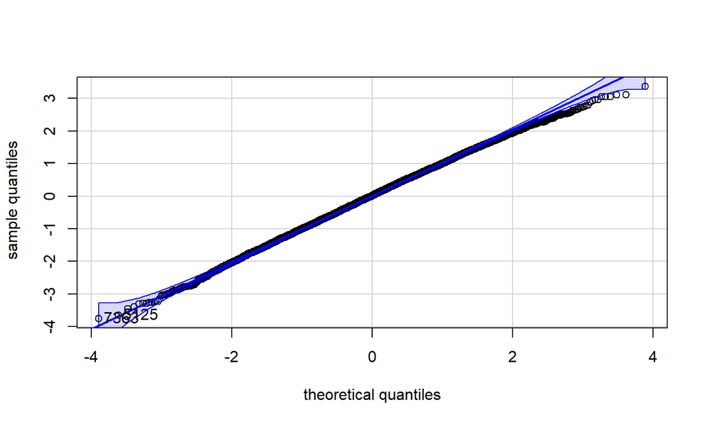

```
## [1] 7363 5125
```

- n = 50

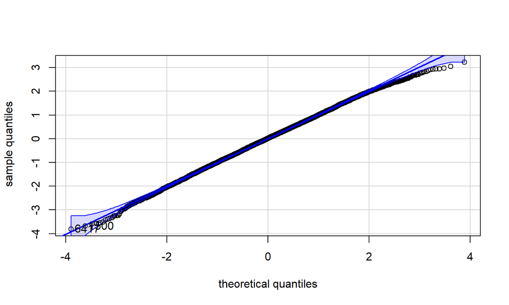

```
## [1] 6417 1500
```

- n = 100

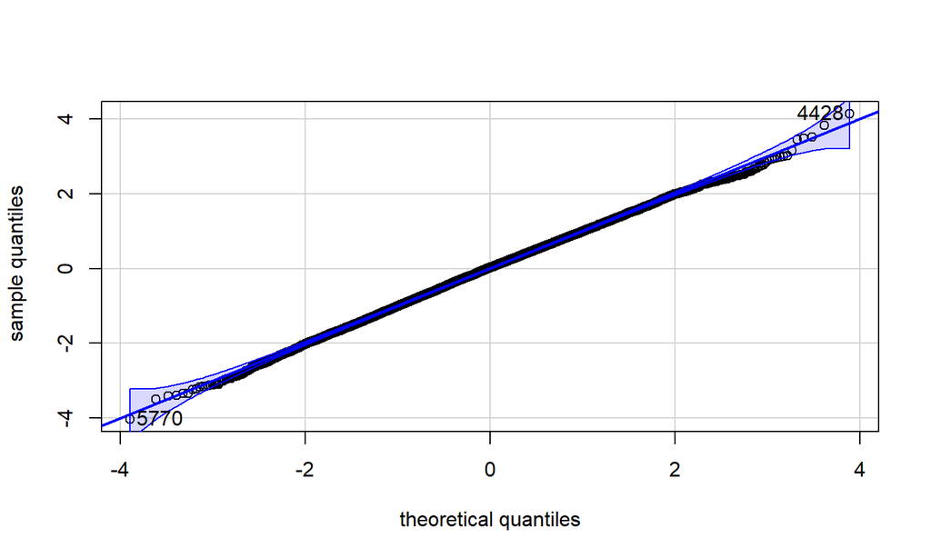

```
## [1] 4428 5770
```

- n = 200

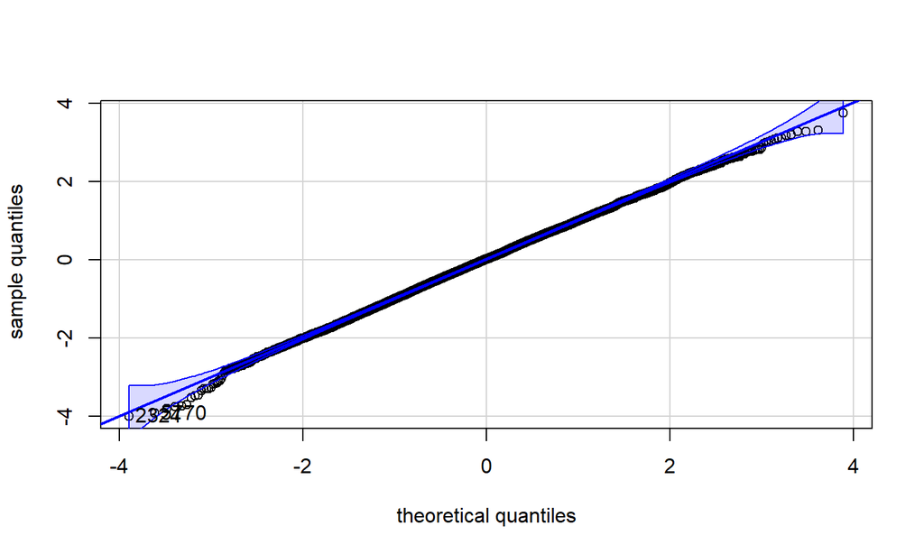

```
## [1] 2324 5770
```

- n = 250

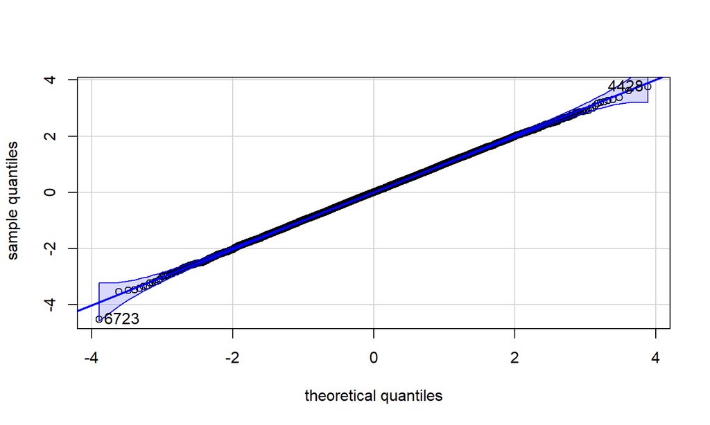

```
## [1] 6723 4428
```

- n = 300

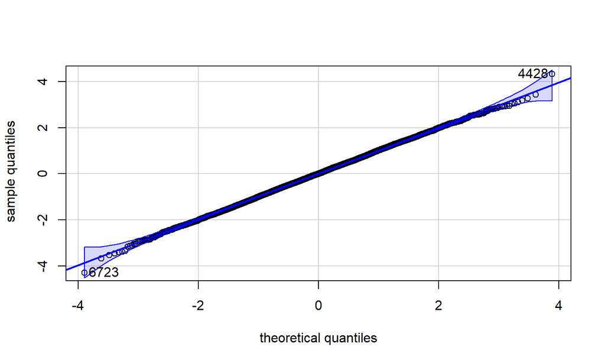

```
## [1] 4428 6723
```

## Goodness of fit with normal(0,1)

```
##   sample size      p value
## 1          10 1.187578e-17
## 2          20 4.153795e-04
## 3          30 3.271296e-01
## 4          50 8.355390e-01
## 5         100 8.209325e-02
## 6         200 5.437517e-01
## 7         250 8.585630e-01
## 8         300 9.228470e-01
```

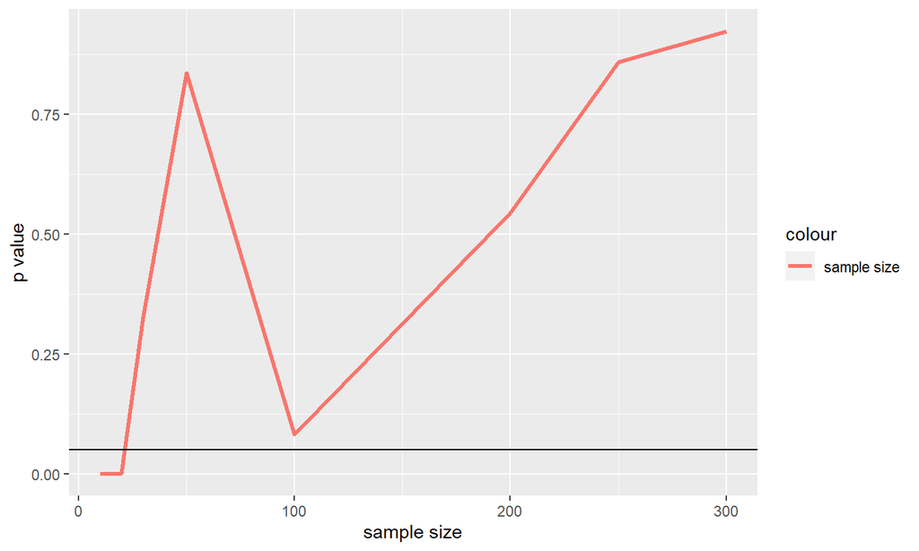

## Size Estimations of left sided test for n = 7,10,13,16,20,23,27,30

- Take critical point with respect to size 0.05

```
##   sample size est. size
## 1           7  0.038840
## 2          10  0.042121
## 3          13  0.047390
## 4          16  0.046917
## 5          20  0.048771
## 6          23  0.049195
## 7          27  0.047703
## 8          30  0.048162
```

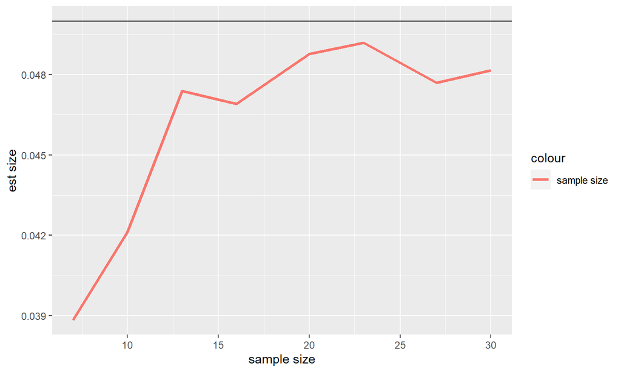

- estimated size always less than 0.05

## Size Estimations of right tailed test for n = 7,10,13,16,20,23,27,30

```
##   sample size est. size
## 1           7  0.038995
## 2          10  0.080936
## 3          13  0.047376
## 4          16  0.046974
## 5          20  0.048761
## 6          23  0.049057
## 7          27  0.047948
## 8          30  0.048189
```

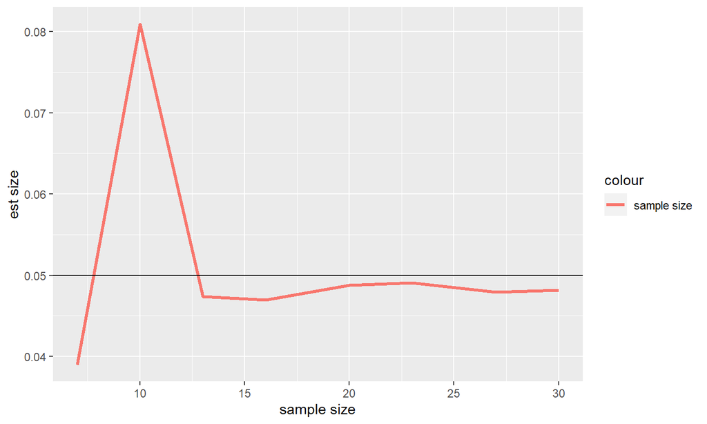

- estimated size closes to 0.05 for sample size, n between 15 to 30

## Size Estimations of both tailed test for n = 7,10,13,16,20,23,27,30

```
##   sample size est. size
## 1           7  0.046602
## 2          10  0.048464
## 3          13  0.047564
## 4          16  0.044288
## 5          20  0.047944
## 6          23  0.048546
## 7          27  0.048914
## 8          30  0.049386
```

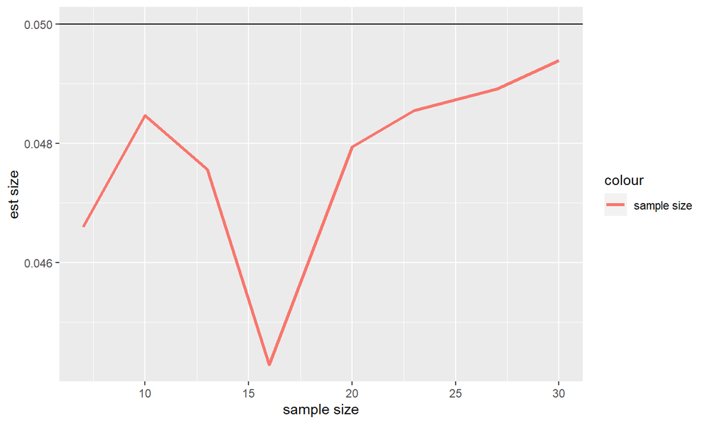

- estimated size has a increasing trend for sample size between 15 to 30

## Power Function and its comparision with parametric counterpart

### Power Curves for fixed sample size

- Case 1 : H0 : $\theta$ = 0 vs H1 : $\theta$ > 0
- Case 2 : H0 : $\theta$ = 0 vs H1 : $\theta$ < 0
- Case 3 : H0 : $\theta$ = 0 vs H1 : $\theta$ $\neq$ 0

### Power Curves for for fixed $\theta$ and varying sample size

- Case 1 : $\theta$ > 0
- Case 2 : $\theta$ < 0

### Comparision with parametric counterpart

- Case 1 : Comparision of Power Curve for testing H0 : $\theta$ = 0 vs H1 : $\theta$ > 0 when sample is drawn from Normal population with location parameter $\theta$ (Using t test as well as z test)
- Case 2 : Comparision of Power Curve for testing H0 : $\theta$ = 0 vs H1 : $\theta$ < 0 when sample is drawn from Normal population with location parameter $\theta$ (Using t test as well as z test)
- Case 3 :Comparision of Power Curve for testing H0 : $\theta$ = 0 vs H1 : $\theta$ $\neq$ 0 when sample is drawn from Normal population with location parameter $\theta$ (Using t test as well as z test)
- Case 4 ::Comparision of Power Curve for testing H0 : $\theta$ = 0 vs H1 : $\theta$ $\neq$ 0 when sample is drawn from Cauchy population with location parameter $\theta$ (Using t test and asymptotic test for median)
- H0 : $\theta$ = 0 vs H1 : $\theta$ > 0

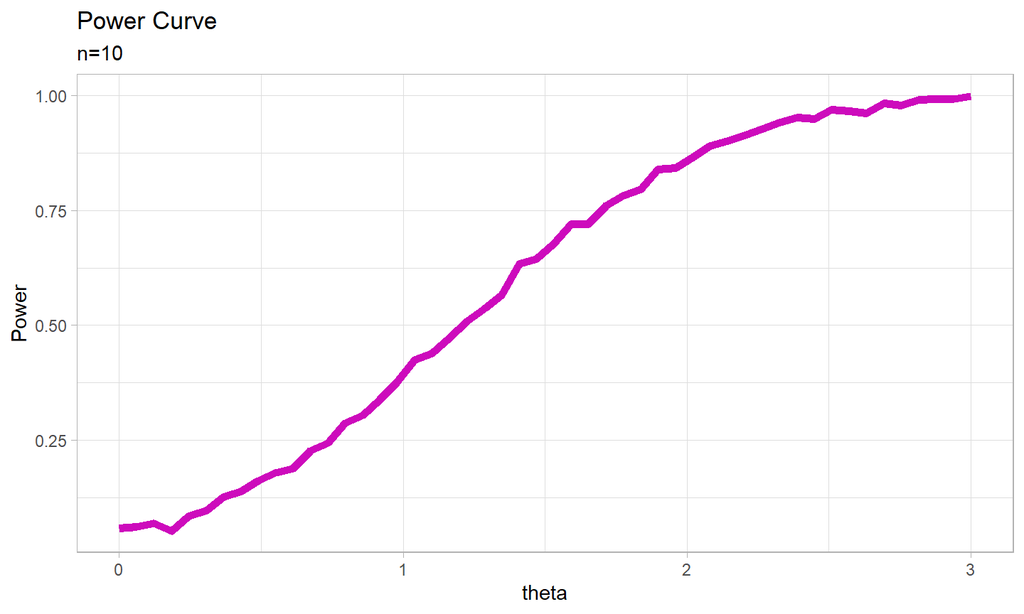

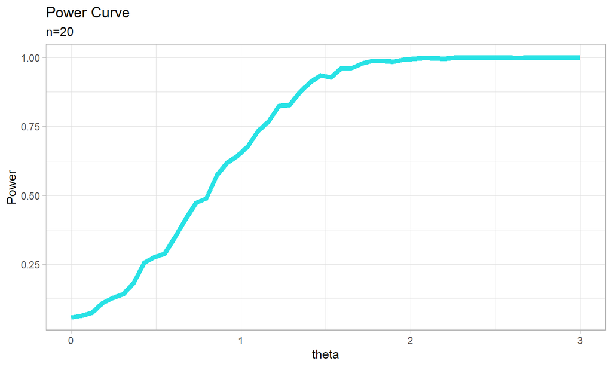

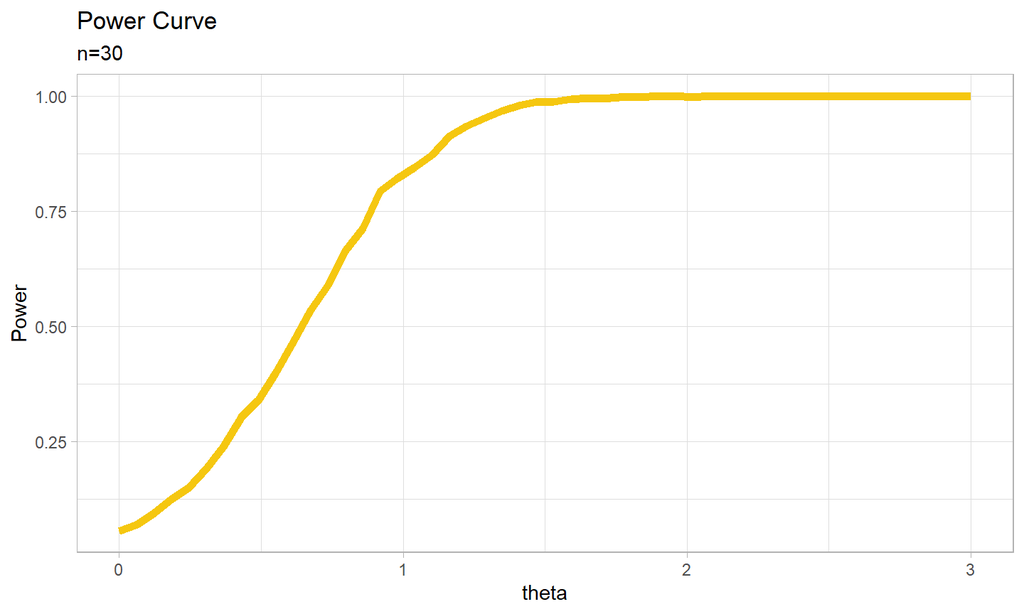

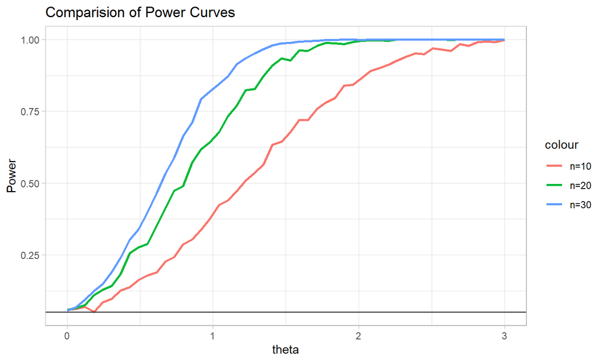

- Observation :
- For fixed theta, here samples are drawn from N($\theta$,2), power converges faster to unity with increase in sample size.
- H0 : $\theta$ = 0 vs H1 : $\theta$ < 0

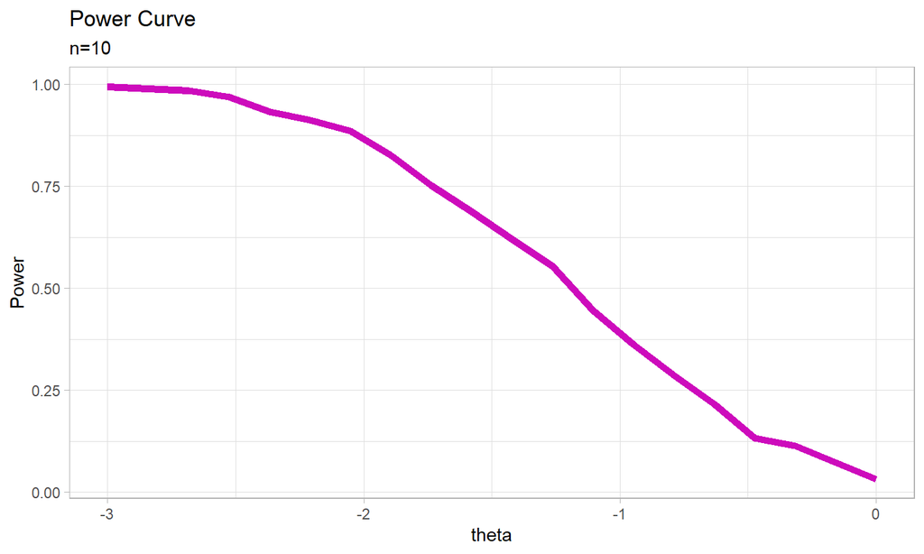